# Ass1

2023-01-09

```r
library(ggplot2)
library(tidyverse)
library(gridExtra)
```

# 1: A 10,000 x 1001 matrix of random numbers drawn from N(0,1)

```r
set.seed(5654)
n <- 10000*1001
data <- rnorm(n,0,1)
matrix <- matrix(data, nrow = 10000, ncol=1001)
#View(matrix)
```

# 2: Treat first column as ‘y’ and the remaining columns as x’s

```r
y <- matrix[,1]
x <- matrix[,-1]
```

# 3: Regress y on x’s. Is an intercept needed? Why (not)?

```r
model <- glm(y~x+0)
summary(model)
```

```
##
## Call:
## glm(formula = y ~ x + 0)
##
## Deviance Residuals:
##     Min       1Q   Median       3Q      Max
## -3.3213  -0.6242   0.0057   0.6328   3.4828
##
## Coefficients:
##         Estimate Std. Error t value Pr(>|t|)
## x1    -4.267e-03  1.039e-02  -0.411 0.681181
## x2    -1.551e-02  1.037e-02  -1.495 0.134822
## x3     7.146e-04  1.044e-02   0.068 0.945404
## x4     1.024e-02  1.048e-02   0.977 0.328373
## x5     1.169e-02  1.045e-02   1.118 0.263548
## x6     4.145e-03  1.037e-02   0.400 0.689412
## x7     6.779e-03  1.036e-02   0.654 0.512870
## x8     1.330e-02  1.041e-02   1.278 0.201407
## x9     2.245e-03  1.044e-02   0.215 0.829822
## x10   -1.371e-02  1.038e-02  -1.321 0.186688
## x11   -1.061e-02  1.040e-02  -1.020 0.307722
## x12    1.621e-02  1.037e-02   1.563 0.118029
## x13    8.073e-03  1.034e-02   0.781 0.434846
## x14   -9.201e-03  1.036e-02  -0.888 0.374491
## x15    1.147e-02  1.041e-02   1.101 0.270777
## x16    1.093e-02  1.042e-02   1.049 0.294422
## x17    2.920e-03  1.042e-02   0.280 0.779414
## x18   -2.006e-02  1.038e-02  -1.932 0.053392 .
## x19   -6.423e-03  1.041e-02  -0.617 0.537086
## x20   -3.865e-03  1.036e-02  -0.373 0.708971
## x21    6.321e-03  1.054e-02   0.600 0.548611
## x22    8.038e-03  1.035e-02   0.776 0.437518
## x23    1.843e-02  1.045e-02   1.763 0.077943 .
## x24    8.154e-03  1.037e-02   0.787 0.431573
## x25    2.205e-03  1.018e-02   0.217 0.828592
## x26   -5.852e-03  1.040e-02  -0.563 0.573603
## x27    9.745e-03  1.035e-02   0.942 0.346213
## x28   -6.292e-03  1.033e-02  -0.609 0.542282
## x29   -8.292e-03  1.035e-02  -0.801 0.422939
## x30   -1.805e-03  1.036e-02  -0.174 0.861685
```

[output cut: 965 more lines]

```
## x996   6.527e-03  1.036e-02   0.630 0.528888
## x997  -1.648e-03  1.040e-02  -0.158 0.874099
## x998  -8.997e-04  1.046e-02  -0.086 0.931433
## x999   8.935e-03  1.045e-02   0.855 0.392451
## x1000  1.345e-03  1.048e-02   0.128 0.897913
## ---
## Signif. codes:  0 '***' 0.001 '**' 0.01 '*' 0.05 '.' 0.1 ' ' 1
##
## (Dispersion parameter for gaussian family taken to be 0.9716497)
##
##     Null deviance: 9700.2  on 10000  degrees of freedom
## Residual deviance: 8744.8  on  9000  degrees of freedom
## AIC: 29040
##
## Number of Fisher Scoring iterations: 2
```

```r
print("An intercept is not needed as we do the sampling from a standard normal distirbution with zero mean.")
```

```
## [1] "An intercept is not needed as we do the sampling from a standard normal distirbution with zero mean."
```

# 4: A histogram of the p-values from the regression in Q3

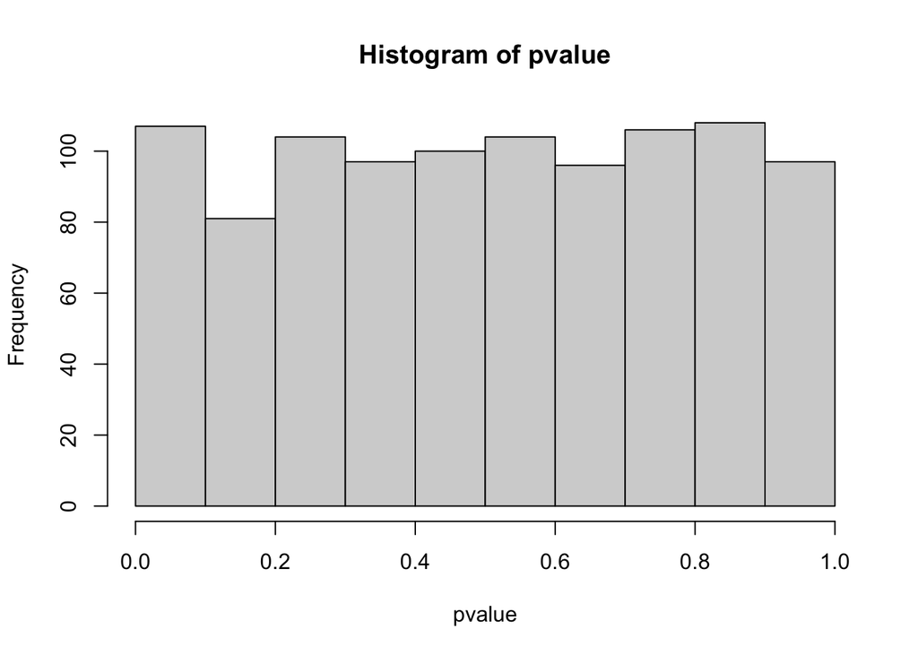

```r
pvalue <- summary(model)$coefficient[,4]
hist(pvalue)
```

```r
ks.test(pvalue, "punif") # Null hypothesis is that output distribution is uniform
```

```
##
##  Asymptotic one-sample Kolmogorov-Smirnov test
##
## data:  pvalue
## D = 0.021705, p-value = 0.7338
## alternative hypothesis: two-sided
```

```r
print("The histogram look likes a uniform distribution.")
```

```
## [1] "The histogram look likes a uniform distribution."
```

# 5: How many ‘significant’ variables do you expect to find knowing how the data was generated? How many ‘significant’ variables does the regression yeild if alpha = 0.01? What does this tell us?

```r
(table(pvalue<0.01))
```

```
##
## FALSE  TRUE
##   988    12
```

# 6: Use the BH procedure to control the FDR with a q of 0.1. How many ‘true’ discoveries do you estimate?

```r
q <- 0.1
ranked_p <- sort(pvalue)
k <- seq(1,length(ranked_p),1)
pstar <- q*(k/length(ranked_p))
compare <- ranked_p < pstar
table <- cbind(ranked_p,k,pstar, compare)
#View(table)
table(table[compare])
```

```
## < table of extent 0 >
```

```r
print("None 'true' discovery founded.")
```

```
## [1] "None 'true' discovery founded."
```

# 7: Explore the “autos.csv” data. Include any metrics and / or plots you find interesting

```r
autos <- read.csv("/Users/zhongjinying/Desktop/autos.csv")
head(autos)
```

```
##          make fuel_type aspiration num_of_doors  body_style drive_wheels
## 1 alfa-romero       gas        std          two convertible          rwd
## 2 alfa-romero       gas        std          two convertible          rwd
## 3 alfa-romero       gas        std          two   hatchback          rwd
## 4        audi       gas        std         four       sedan          fwd
## 5        audi       gas        std         four       sedan          4wd
## 6        audi       gas        std          two       sedan          fwd
##   engine_location wheel_base length width height curb_weight engine_type
## 1           front       88.6  168.8  64.1   48.8        2548        dohc
## 2           front       88.6  168.8  64.1   48.8        2548        dohc
## 3           front       94.5  171.2  65.5   52.4        2823        ohcv
## 4           front       99.8  176.6  66.2   54.3        2337         ohc
## 5           front       99.4  176.6  66.4   54.3        2824         ohc
## 6           front       99.8  177.3  66.3   53.1        2507         ohc
##   num_of_cylinders engine_size fuel_system bore stroke compression_ratio
## 1                4         130        mpfi 3.47   2.68               9.0
## 2                4         130        mpfi 3.47   2.68               9.0
## 3                6         152        mpfi 2.68   3.47               9.0
## 4                4         109        mpfi 3.19   3.40              10.0
## 5                5         136        mpfi 3.19   3.40               8.0
## 6                5         136        mpfi 3.19   3.40               8.5
##   horsepower peak_rpm city_mpg highway_mpg price
## 1        111     5000       21          27 13495
## 2        111     5000       21          27 16500
## 3        154     5000       19          26 16500
## 4        102     5500       24          30 13950
## 5        115     5500       18          22 17450
## 6        110     5500       19          25 15250
```

## (a) Correlation matrix between numerical variables

```r
autos_onlynum <- cbind(autos[,8:12],autos[,14:15],autos[,17:ncol(autos)])
Hmisc::rcorr(as.matrix(autos_onlynum))
```

```
##                   wheel_base length width height curb_weight num_of_cylinders
## wheel_base              1.00   0.88  0.82   0.59        0.78             0.34
## length                  0.88   1.00  0.86   0.49        0.88             0.45
## width                   0.82   0.86  1.00   0.31        0.87             0.55
## height                  0.59   0.49  0.31   1.00        0.31            -0.08
## curb_weight             0.78   0.88  0.87   0.31        1.00             0.62
## num_of_cylinders        0.34   0.45  0.55  -0.08        0.62             1.00
## engine_size             0.57   0.69  0.74   0.03        0.86             0.85
## bore                    0.50   0.61  0.54   0.18        0.65             0.22
## stroke                  0.17   0.12  0.19  -0.05        0.18             0.02
## compression_ratio       0.25   0.16  0.19   0.25        0.16            -0.03
## horsepower              0.38   0.59  0.62  -0.08        0.76             0.72
## peak_rpm               -0.35  -0.28 -0.25  -0.26       -0.28            -0.07
## city_mpg               -0.50  -0.70 -0.66  -0.11       -0.78            -0.54
## highway_mpg            -0.57  -0.73 -0.70  -0.16       -0.82            -0.56
## price                   0.58   0.70  0.75   0.14        0.84             0.75
##                   engine_size  bore stroke compression_ratio horsepower
## wheel_base               0.57  0.50   0.17              0.25       0.38
## length                   0.69  0.61   0.12              0.16       0.59
## width                    0.74  0.54   0.19              0.19       0.62
## height                   0.03  0.18  -0.05              0.25      -0.08
## curb_weight              0.86  0.65   0.18              0.16       0.76
## num_of_cylinders         0.85  0.22   0.02             -0.03       0.72
## engine_size              1.00  0.58   0.21              0.03       0.85
## bore                     0.58  1.00  -0.07              0.00       0.57
## stroke                   0.21 -0.07   1.00              0.20       0.10
## compression_ratio        0.03  0.00   0.20              1.00      -0.20
## horsepower               0.85  0.57   0.10             -0.20       1.00
## peak_rpm                -0.22 -0.27  -0.07             -0.44       0.10
## city_mpg                -0.72 -0.60  -0.03              0.31      -0.83
## highway_mpg             -0.74 -0.61  -0.04              0.25      -0.81
## price                    0.89  0.55   0.10              0.07       0.81
##                   peak_rpm city_mpg highway_mpg price
## wheel_base           -0.35    -0.50       -0.57  0.58
## length               -0.28    -0.70       -0.73  0.70
## width                -0.25    -0.66       -0.70  0.75
## height               -0.26    -0.11       -0.16  0.14
## curb_weight          -0.28    -0.78       -0.82  0.84
## num_of_cylinders     -0.07    -0.54       -0.56  0.75
## engine_size          -0.22    -0.72       -0.74  0.89
```

[output cut: 46 more lines]

```
## wheel_base        0.0000   0.0000   0.0000      0.0000
## length            0.0001   0.0000   0.0000      0.0000
## width             0.0005   0.0000   0.0000      0.0000
## height            0.0003   0.1238   0.0264      0.0589
## curb_weight       0.0000   0.0000   0.0000      0.0000
## num_of_cylinders  0.3018   0.0000   0.0000      0.0000
## engine_size       0.0023   0.0000   0.0000      0.0000
## bore              0.0001   0.0000   0.0000      0.0000
## stroke            0.3444   0.6662   0.5781      0.1841
## compression_ratio 0.0000   0.0000   0.0005      0.3033
## horsepower        0.1606   0.0000   0.0000      0.0000
## peak_rpm                   0.3991   0.9076      0.1507
## city_mpg          0.3991            0.0000      0.0000
## highway_mpg       0.9076   0.0000               0.0000
## price             0.1507   0.0000   0.0000
```

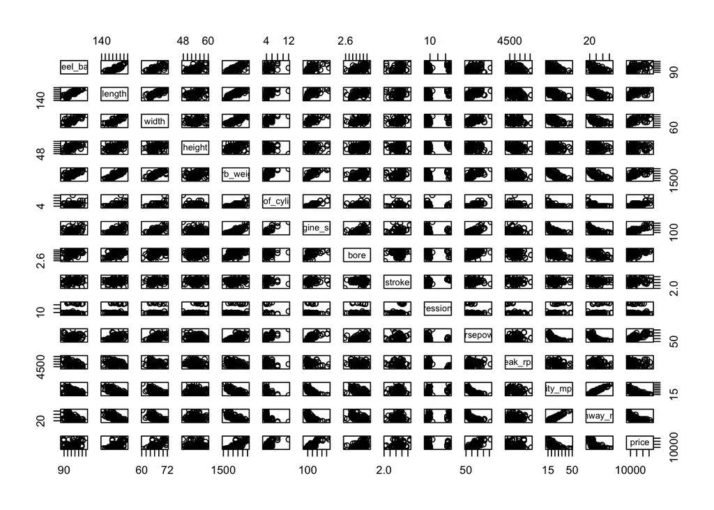

```r
plot(autos_onlynum)
```

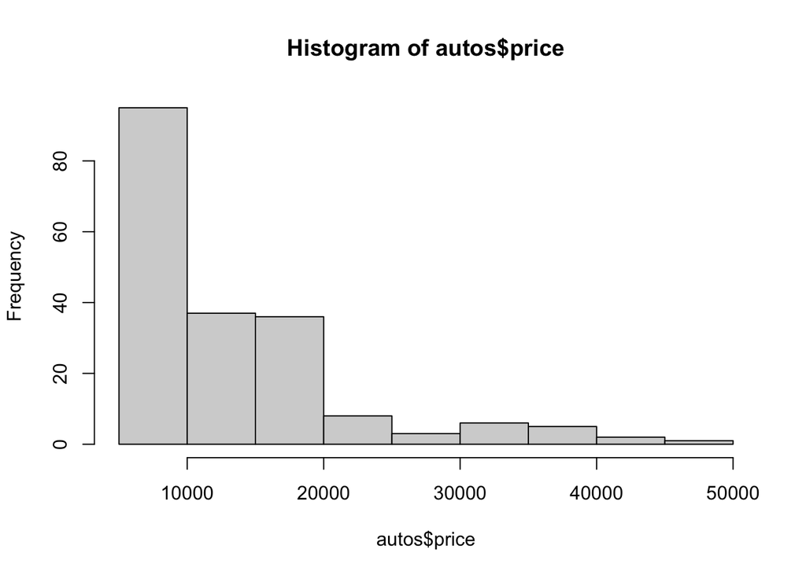

```r
hist(autos$price)
```

```r
print("The distribution of Price variable is not normal and the prices mainly locates less than 20000.")
```

```
## [1] "The distribution of Price variable is not normal and the prices mainly locates less than 20000."
```

correlations with Price variable: 1) positive (>0.7): length, width, curb weight, num_of_cylinders, engine size, horsepower; 2) negative (abs>0.7): city mpg, highway mpg.

other variables’ positive relationships: 1) wheel base ~ width ~ length ~ curb weight; curb weight ~ engine size; 2) city mpg ~ highway mpg

other variables’ negative relationships: 1) wheel base ~ city/highway mpg 2) horsepower ~ city/highway mpg

## (b) Price by different categorical variables

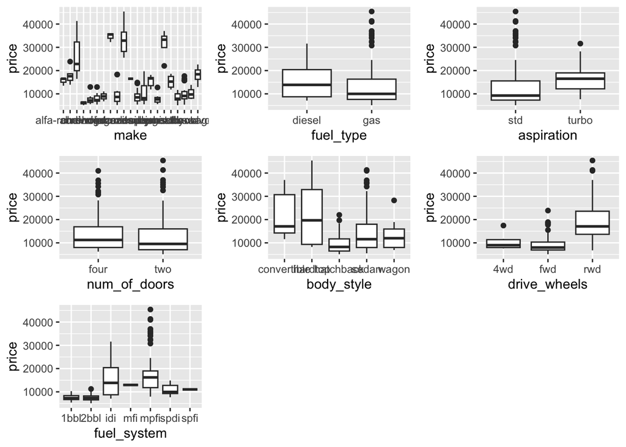

```r
### price distribution among different car makers
### for premium price tier, bmw and mercedes-benz have wider price distribution; jaguar and porsche have relative more narrow distribution
a <- ggplot(autos, aes(x=make, y=price)) + geom_boxplot()
b <- ggplot(autos, aes(x=fuel_type, y=price)) + geom_boxplot()
c <- ggplot(autos, aes(x=aspiration, y=price)) + geom_boxplot()
d <- ggplot(autos, aes(x=num_of_doors, y=price)) + geom_boxplot()
e <- ggplot(autos, aes(x=body_style, y=price)) + geom_boxplot()
f <- ggplot(autos, aes(x=drive_wheels, y=price)) + geom_boxplot()
g <- ggplot(autos, aes(x=fuel_system, y=price)) + geom_boxplot()
grid.arrange(a,b,c,d,e,f,g)
```

## (c) Other graphs

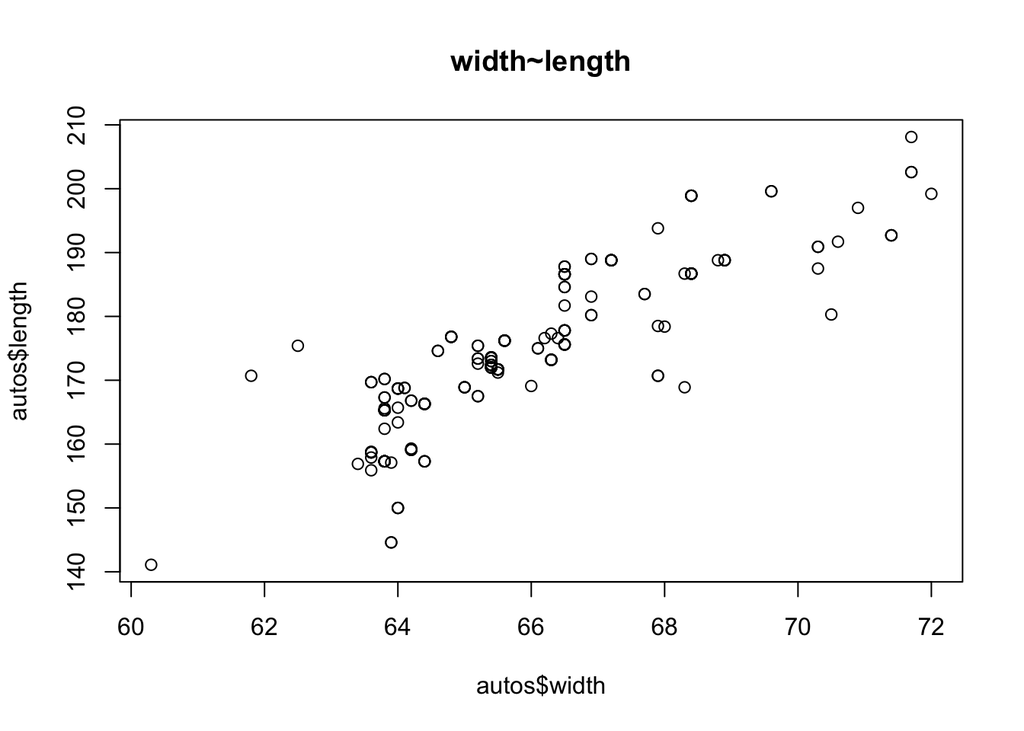

```r
plot(autos$width, autos$length, main = 'width~length')
```

```r
print("Positive and strong correlation between width and length.")
```

```
## [1] "Positive and strong correlation between width and length."
```

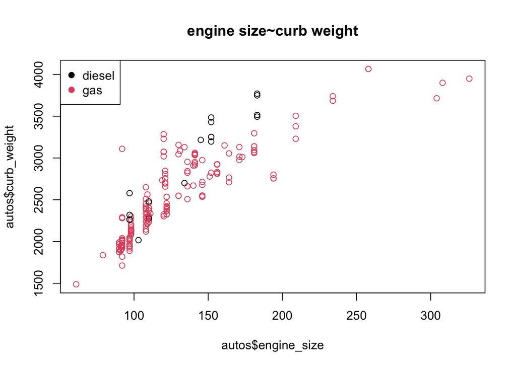

```r
plot(autos$engine_size, autos$curb_weight,
     main = 'engine size~curb weight', col=as.factor(autos$fuel_type))
legend("topleft",
       legend = levels(factor(autos$fuel_type)),
       pch = 19,
       col = factor(levels(factor(autos$fuel_type))))
```

```r
print("Positive relationship between engine size and curb weight for both diesel and gas fuel types. The larger engine sizes need heavier curbs.")
```

```
## [1] "Positive relationship between engine size and curb weight for both diesel and gas fuel types. The larger engine sizes need heavier curbs."
```

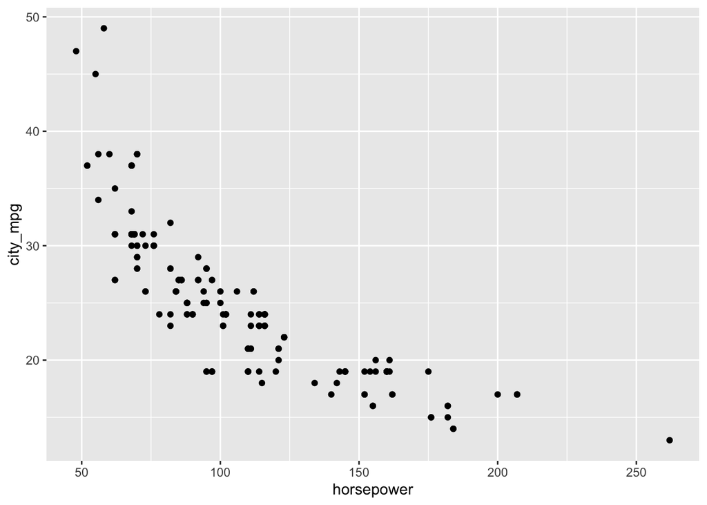

```r
ggplot(data=autos,mapping=aes(x=horsepower,y=city_mpg))+
  geom_point()
```

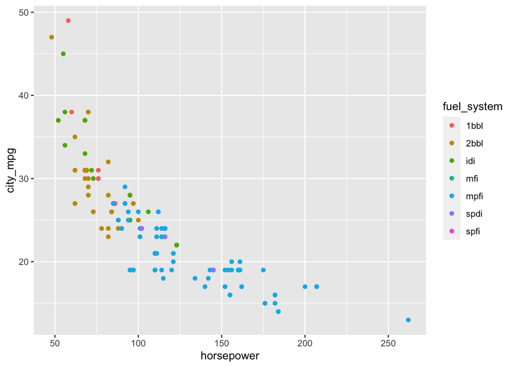

```r
ggplot(data=autos,mapping=aes(x=horsepower,y=city_mpg,group=fuel_system))+
  geom_point(aes(color=fuel_system))
```

```r
print("Negative relationship between horsepower and mpg.'mpfi' fuel system has relative higher levels of horsepower, horsepower of other systems mainly lies between 50 to 100.")
```

```
## [1] "Negative relationship between horsepower and mpg.'mpfi' fuel system has relative higher levels of horsepower, horsepower of other systems mainly lies between 50 to 100."
```

# 8: Create a linear regression model to predict price. Explain your model.

```r
model2 <- lm(price~make+fuel_type+aspiration+num_of_doors+body_style +drive_wheels+engine_location+wheel_base+length+width+height+curb_weight+engine_type+num_of_cylinders+engine_size+fuel_system+bore+stroke+compression_ratio+horsepower+peak_rpm+city_mpg+highway_mpg, data=autos)
summary(model2)
```

```
##
## Call:
## lm(formula = price ~ make + fuel_type + aspiration + num_of_doors +
##     body_style + drive_wheels + engine_location + wheel_base +
##     length + width + height + curb_weight + engine_type + num_of_cylinders +
##     engine_size + fuel_system + bore + stroke + compression_ratio +
##     horsepower + peak_rpm + city_mpg + highway_mpg, data = autos)
##
## Residuals:
##     Min      1Q  Median      3Q     Max
## -3599.8  -989.6     0.0   838.2  8663.6
##
## Coefficients: (2 not defined because of singularities)
##                       Estimate Std. Error t value Pr(>|t|)
## (Intercept)         -1.082e+04  1.790e+04  -0.605 0.546359
## makeaudi            -1.098e+02  2.077e+03  -0.053 0.957900
## makebmw              6.279e+03  2.010e+03   3.125 0.002164 **
## makechevrolet       -4.753e+03  2.295e+03  -2.071 0.040205 *
## makedodge           -4.996e+03  1.901e+03  -2.627 0.009563 **
## makehonda           -1.534e+03  2.222e+03  -0.691 0.490957
## makeisuzu           -3.213e+03  2.543e+03  -1.264 0.208387
## makejaguar          -1.538e+03  2.571e+03  -0.598 0.550808
## makemazda           -1.811e+03  1.680e+03  -1.078 0.282928
## makemercedes-benz    2.773e+03  2.251e+03   1.232 0.220188
## makemercury         -1.978e+03  2.732e+03  -0.724 0.470305
## makemitsubishi      -5.593e+03  1.880e+03  -2.976 0.003445 **
## makenissan          -2.875e+03  1.633e+03  -1.760 0.080512 .
## makepeugot          -9.279e+03  3.313e+03  -2.801 0.005822 **
## makeplymouth        -5.227e+03  1.876e+03  -2.786 0.006076 **
## makeporsche          5.374e+03  2.718e+03   1.977 0.050019 .
## makesaab             2.225e+03  1.869e+03   1.190 0.235958
## makesubaru          -1.728e+03  1.954e+03  -0.884 0.378258
## maketoyota          -2.898e+03  1.553e+03  -1.866 0.064099 .
## makevolkswagen      -1.788e+03  1.731e+03  -1.033 0.303490
## makevolvo           -8.789e+02  2.043e+03  -0.430 0.667685
## fuel_typegas        -1.484e+04  6.100e+03  -2.433 0.016254 *
## aspirationturbo      2.179e+03  8.372e+02   2.603 0.010230 *
## num_of_doorstwo     -3.635e+02  4.977e+02  -0.730 0.466367
## body_stylehardtop   -3.086e+03  1.206e+03  -2.560 0.011533 *
## body_stylehatchback -4.011e+03  1.110e+03  -3.614 0.000420 ***
```

[output cut: 20 more lines]

```
## fuel_systemspdi      1.243e+03  1.890e+03   0.658 0.511740
## fuel_systemspfi      3.514e+03  3.143e+03   1.118 0.265533
## bore                -3.668e+03  1.489e+03  -2.463 0.014973 *
## stroke              -1.188e+03  9.225e+02  -1.288 0.199801
## compression_ratio   -1.054e+03  4.325e+02  -2.436 0.016096 *
## horsepower          -5.590e+00  2.180e+01  -0.256 0.797992
## peak_rpm             2.350e+00  6.542e-01   3.592 0.000453 ***
## city_mpg             3.818e+01  1.377e+02   0.277 0.781955
## highway_mpg          1.273e+02  1.194e+02   1.066 0.288479
## ---
## Signif. codes:  0 '***' 0.001 '**' 0.01 '*' 0.05 '.' 0.1 ' ' 1
##
## Residual standard error: 1819 on 140 degrees of freedom
## Multiple R-squared:  0.9631, Adjusted R-squared:  0.9495
## F-statistic: 70.35 on 52 and 140 DF,  p-value: < 2.2e-16
```

```r
#model3 <- lm(price~., data=autos)
#View(summary(model3))
print("The model contains intercept, dummy variables created for categorical variables and numerical variables. The reason to include intercept is that there are random errors in the dataset and dummy variables created in the model. Besides, all the factors are included as they all could potentialy be related to the price variable and impact the the final price prediction. ")
```

[output not shown]

# 9: Why might false discoveries be an issue?

1. False discoveries will negatively influence the accuracy of the model and its prediction. i.e., if the model wrongly includes insignificant variables, then the price prediction will be biased.
2. This model has over 50 variables and 22 variables are tested as ‘statistically significant’.
3. Let’s say the alpha is 5%, also suppose that half of all the regression coefficients are actually influential and that we find all of them significant. Still, around 2 (=52/2*0.05) tests would be wrongly put as significant. That is, around 10% of significant tests are false discoveries.
4. Also, for every 10 variables added in the model esp. for dummy variables and an alpha of 0.05, the expected number of false detection will increase by 0.5 accordingly, which is not a good thing. Thus, the false discoveries might be an issue.

# 10: Use the BH procedure to control the FDR with a q of 0.1. How many true discoveries do you estimate? Plot the cutoff line together with the significant and insignificant p-values.

```r
qauto <- 0.1
pvals <- summary(model2)$coefficient[-1,4]
psorted <- sort(pvals)
prank <- seq(1,length(psorted),1)
pnew <- qauto*(prank/length(psorted))
tag <- psorted <= pnew
table2 <- cbind(prank,pvals,psorted,pnew,tag)
#View(table2)
table(tag)
```

```
## tag
## FALSE  TRUE
##    33    19
```

```r
print("There are 19 true discoveries.")
```

```
## [1] "There are 19 true discoveries."
```

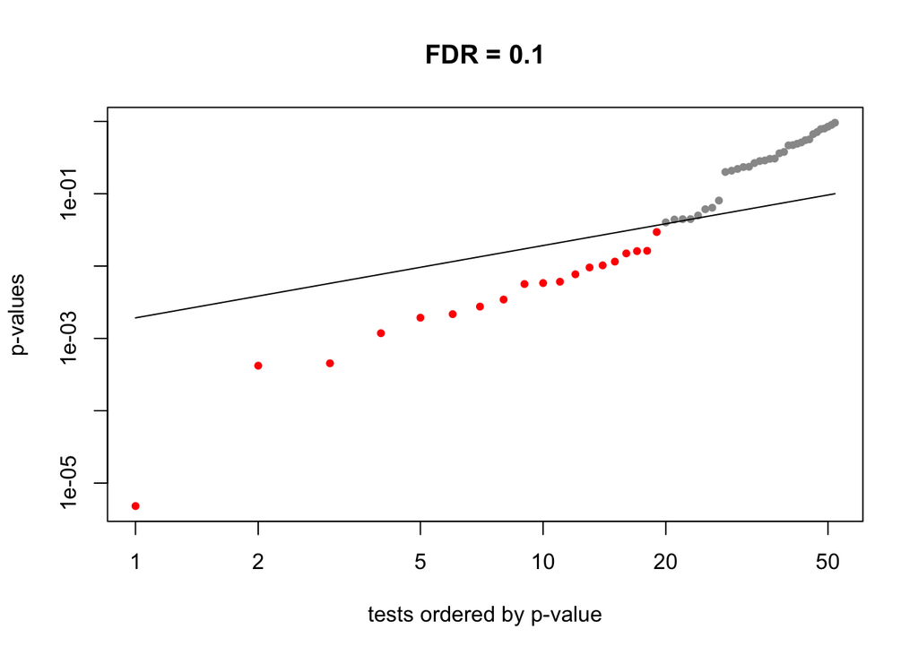

```
## [1] 0.02956354
```

```r
## extract p-value cutoff for E[fdf] < q
fdr <- function(pvals, q, plotit){
  pvals <- pvals[!is.na(pvals)]
  N <- length(pvals)

  k <- rank(pvals, ties.method="min")
  alpha <- max(pvals[ pvals <= (q*k/N) ])

  if(plotit){
    sig <- factor(pvals <= alpha)
    o <- order(pvals)
    plot(pvals[o], log="xy", col=c("grey60","red")[sig[o]], pch=20,
      ylab="p-values", xlab="tests ordered by p-value", main = paste('FDR =',q))
    lines(1:N, q*(1:N) / N)
  }

  return(alpha)
}
(fdr(pvals, q, plotit=TRUE))
```

```r
print("The cutoff value is 0.02956354.")
```

```
## [1] "The cutoff value is 0.02956354."
```